# Project: Investigate a Dataset No-show Appointments

- Introduction
- Data Wrangling
- Exploratory Data Analysis
- Conclusions
- Limitations

## Introduction

> In this project i am going to be analyzing data of patient appointment, the main goal is to predict if patient will show up for their scheduled appointment or not and to determine how patients who show up for their appointment differs from patients who do not show up for their appointment. The dataset collects information from 100 thousands medical appointments in Brazil and is focused on whether or not patients show up for their appointment. A number of characteristics about the patient are included in each row.Some of the vital columns i have to pay attention to when analyzing the data are, **ScheduledDay** which provides data on what day the patient set up their appointment.

> **Neighborhood** which provides data on the location of the hospital.

> **Scholarship** which provides data on whether or not the patient is enrolled in Brasilian welfare program Bolsa Família.

> **No-show** provides data of wether patient will show up for the appointment or not

> **Neighborhood** provides data of where the patient live.

> > My Independent variables here are **ScheduledDay**, **Scholarship** and **Handicap**. And my dependent variable is No-show

> All the the python modules needed for this project are been loaded below with their alias

```python
import pandas as pd
import numpy as np
import matplotlib.pyplot as plt
%matplotlib inline
import datetime as dt
```

## Data Wrangling

### General Properties

```python
# Load your data and print out a few lines.
df = pd.read_csv('noshowappointments-kagglev2-may-2016.csv')
df.head()
```

|  | PatientId | AppointmentID | Gender | ScheduledDay | AppointmentDay | Age | Neighbourhood | Scholarship | Hipertension | Diabetes | Alcoholism | Handcap | SMS_received | No-show |
| --- | --- | --- | --- | --- | --- | --- | --- | --- | --- | --- | --- | --- | --- | --- |
| 0 | 2.987250e+13 | 5642903 | F | 2016-04-29T18:38:08Z | 2016-04-29T00:00:00Z | 62 | JARDIM DA PENHA | 0 | 1 | 0 | 0 | 0 | 0 | No |
| 1 | 5.589978e+14 | 5642503 | M | 2016-04-29T16:08:27Z | 2016-04-29T00:00:00Z | 56 | JARDIM DA PENHA | 0 | 0 | 0 | 0 | 0 | 0 | No |
| 2 | 4.262962e+12 | 5642549 | F | 2016-04-29T16:19:04Z | 2016-04-29T00:00:00Z | 62 | MATA DA PRAIA | 0 | 0 | 0 | 0 | 0 | 0 | No |
| 3 | 8.679512e+11 | 5642828 | F | 2016-04-29T17:29:31Z | 2016-04-29T00:00:00Z | 8 | PONTAL DE CAMBURI | 0 | 0 | 0 | 0 | 0 | 0 | No |
| 4 | 8.841186e+12 | 5642494 | F | 2016-04-29T16:07:23Z | 2016-04-29T00:00:00Z | 56 | JARDIM DA PENHA | 0 | 1 | 1 | 0 | 0 | 0 | No |

> The code below Get the Total rows and columns in the dataset

```python
#code to show the number of rows and columns in the dataset
df.shape
```

```
(110527, 14)
```

> The code below returns description of data in a dataframe or statistics of the data in the dataset

```python
#Povides statistical description of the dataset
df.describe()
```

|  | PatientId | AppointmentID | Age | Scholarship | Hipertension | Diabetes | Alcoholism | Handcap | SMS_received |
| --- | --- | --- | --- | --- | --- | --- | --- | --- | --- |
| count | 1.105270e+05 | 1.105270e+05 | 110527.000000 | 110527.000000 | 110527.000000 | 110527.000000 | 110527.000000 | 110527.000000 | 110527.000000 |
| mean | 1.474963e+14 | 5.675305e+06 | 37.088874 | 0.098266 | 0.197246 | 0.071865 | 0.030400 | 0.022248 | 0.321026 |
| std | 2.560949e+14 | 7.129575e+04 | 23.110205 | 0.297675 | 0.397921 | 0.258265 | 0.171686 | 0.161543 | 0.466873 |
| min | 3.921784e+04 | 5.030230e+06 | -1.000000 | 0.000000 | 0.000000 | 0.000000 | 0.000000 | 0.000000 | 0.000000 |
| 25% | 4.172614e+12 | 5.640286e+06 | 18.000000 | 0.000000 | 0.000000 | 0.000000 | 0.000000 | 0.000000 | 0.000000 |
| 50% | 3.173184e+13 | 5.680573e+06 | 37.000000 | 0.000000 | 0.000000 | 0.000000 | 0.000000 | 0.000000 | 0.000000 |
| 75% | 9.439172e+13 | 5.725524e+06 | 55.000000 | 0.000000 | 0.000000 | 0.000000 | 0.000000 | 0.000000 | 1.000000 |
| max | 9.999816e+14 | 5.790484e+06 | 115.000000 | 1.000000 | 1.000000 | 1.000000 | 1.000000 | 4.000000 | 1.000000 |

> The code below shows a summary of the entire dataframe

```python
#Prints out concise summary of the dataset
df.info()
```

```
<class 'pandas.core.frame.DataFrame'>
RangeIndex: 110527 entries, 0 to 110526
Data columns (total 14 columns):
 #   Column          Non-Null Count   Dtype
---  ------          --------------   -----
 0   PatientId       110527 non-null  float64
 1   AppointmentID   110527 non-null  int64
 2   Gender          110527 non-null  object
 3   ScheduledDay    110527 non-null  object
 4   AppointmentDay  110527 non-null  object
 5   Age             110527 non-null  int64
 6   Neighbourhood   110527 non-null  object
 7   Scholarship     110527 non-null  int64
 8   Hipertension    110527 non-null  int64
 9   Diabetes        110527 non-null  int64
 10  Alcoholism      110527 non-null  int64
 11  Handcap         110527 non-null  int64
 12  SMS_received    110527 non-null  int64
 13  No-show         110527 non-null  object
dtypes: float64(1), int64(8), object(5)
memory usage: 11.8+ MB
```

> The code below returns the datatype of each column in the dataframe

```python
#Prints out the datatype of all the columns of the dataset
df.dtypes
```

```
PatientId         float64
AppointmentID       int64
Gender             object
ScheduledDay       object
AppointmentDay     object
Age                 int64
Neighbourhood      object
Scholarship         int64
Hipertension        int64
Diabetes            int64
Alcoholism          int64
Handcap             int64
SMS_received        int64
No-show            object
dtype: object
```

> The code below check for Column with null values in the dataframe

```python
#print out the sum of all null values of each column in the dataset
df.isnull().sum()
```

```
PatientId         0
AppointmentID     0
Gender            0
ScheduledDay      0
AppointmentDay    0
Age               0
Neighbourhood     0
Scholarship       0
Hipertension      0
Diabetes          0
Alcoholism        0
Handcap           0
SMS_received      0
No-show           0
dtype: int64
```

> The code below checks if any of columns in the no-show appointment dataframe have null values -The expected result should be False

```python
#prints a boolean to check if there are any null values iin the dataset
df.isnull().sum().any()
```

```
False
```

> The code below check for the number of duplicated values in the dataframe

```python
df.duplicated().sum()
```

```
0
```

### Data Cleaning

> (Here, i want to make sure the data is clean for proper analysis, some of the activities i will be carrying out here are, changing datatype, Renaming and replacing the data of the the No-Show column, Removing unconsistent data from the AppointmentDay, and the ScheduledDay columns and changing their datatypes )

> The code below change all Yes to 1 and all no to 0 in the No-Show column

```python
#Replace the words Yes wth 1 and No with 0
df['No-show'] = df['No-show'].str.replace('Yes','1')
df['No-show'] = df['No-show'].str.replace('No','0')
df.head()
```

|  | PatientId | AppointmentID | Gender | ScheduledDay | AppointmentDay | Age | Neighbourhood | Scholarship | Hipertension | Diabetes | Alcoholism | Handcap | SMS_received | No-show |
| --- | --- | --- | --- | --- | --- | --- | --- | --- | --- | --- | --- | --- | --- | --- |
| 0 | 2.987250e+13 | 5642903 | F | 2016-04-29T18:38:08Z | 2016-04-29T00:00:00Z | 62 | JARDIM DA PENHA | 0 | 1 | 0 | 0 | 0 | 0 | 0 |
| 1 | 5.589978e+14 | 5642503 | M | 2016-04-29T16:08:27Z | 2016-04-29T00:00:00Z | 56 | JARDIM DA PENHA | 0 | 0 | 0 | 0 | 0 | 0 | 0 |
| 2 | 4.262962e+12 | 5642549 | F | 2016-04-29T16:19:04Z | 2016-04-29T00:00:00Z | 62 | MATA DA PRAIA | 0 | 0 | 0 | 0 | 0 | 0 | 0 |
| 3 | 8.679512e+11 | 5642828 | F | 2016-04-29T17:29:31Z | 2016-04-29T00:00:00Z | 8 | PONTAL DE CAMBURI | 0 | 0 | 0 | 0 | 0 | 0 | 0 |
| 4 | 8.841186e+12 | 5642494 | F | 2016-04-29T16:07:23Z | 2016-04-29T00:00:00Z | 56 | JARDIM DA PENHA | 0 | 1 | 1 | 0 | 0 | 0 | 0 |

> The code below change he datatype of the No-Show column to int64, i am converting this column so that i can easily exploy statistics and compare ith other variables

```python
#The code change the datatype of N-Show column to int64
df['No-show'] = df['No-show'].astype('int64')
df.dtypes
```

```
PatientId         float64
AppointmentID       int64
Gender             object
ScheduledDay       object
AppointmentDay     object
Age                 int64
Neighbourhood      object
Scholarship         int64
Hipertension        int64
Diabetes            int64
Alcoholism          int64
Handcap             int64
SMS_received        int64
No-show             int64
dtype: object
```

> The codes below are used to remove the character Z for both columns ScheduledDay and AppointmentDay

```python
#Replace the Letter Z with nothing in the tables of AppointmentDay and ScheduledDay
df['AppointmentDay'] = df['AppointmentDay'].str.replace('Z','')
df['ScheduledDay'] = df['ScheduledDay'].str.replace('Z','')
df.head(4)
```

|  | PatientId | AppointmentID | Gender | ScheduledDay | AppointmentDay | Age | Neighbourhood | Scholarship | Hipertension | Diabetes | Alcoholism | Handcap | SMS_received | No-show |
| --- | --- | --- | --- | --- | --- | --- | --- | --- | --- | --- | --- | --- | --- | --- |
| 0 | 2.987250e+13 | 5642903 | F | 2016-04-29T18:38:08 | 2016-04-29T00:00:00 | 62 | JARDIM DA PENHA | 0 | 1 | 0 | 0 | 0 | 0 | 0 |
| 1 | 5.589978e+14 | 5642503 | M | 2016-04-29T16:08:27 | 2016-04-29T00:00:00 | 56 | JARDIM DA PENHA | 0 | 0 | 0 | 0 | 0 | 0 | 0 |
| 2 | 4.262962e+12 | 5642549 | F | 2016-04-29T16:19:04 | 2016-04-29T00:00:00 | 62 | MATA DA PRAIA | 0 | 0 | 0 | 0 | 0 | 0 | 0 |
| 3 | 8.679512e+11 | 5642828 | F | 2016-04-29T17:29:31 | 2016-04-29T00:00:00 | 8 | PONTAL DE CAMBURI | 0 | 0 | 0 | 0 | 0 | 0 | 0 |

> The code below change the datatype of both AppointmentDay and ScheduledDay to datetime

```python
#The code change the datatype of AppointmentDay and ScheduledDay to datetime
df['AppointmentDay'] = pd.to_datetime(df['AppointmentDay'])
df['ScheduledDay'] = pd.to_datetime(df['ScheduledDay'])
df.dtypes
```

```
PatientId                float64
AppointmentID              int64
Gender                    object
ScheduledDay      datetime64[ns]
AppointmentDay    datetime64[ns]
Age                        int64
Neighbourhood             object
Scholarship                int64
Hipertension               int64
Diabetes                   int64
Alcoholism                 int64
Handcap                    int64
SMS_received               int64
No-show                    int64
dtype: object
```

> The code below split the column ScheduledDay into two, ScheduledDay itself for the date and ScheduledTime for the time

```python
#Code to extract date and time value of the ScheduledDay column and assign them to different variables
df['ScheduledTime'] = df['ScheduledDay'].dt.time
df['ScheduledDay'] = df['ScheduledDay'].dt.date
df.head()
```

|  | PatientId | AppointmentID | Gender | ScheduledDay | AppointmentDay | Age | Neighbourhood | Scholarship | Hipertension | Diabetes | Alcoholism | Handcap | SMS_received | No-show | ScheduledTime |
| --- | --- | --- | --- | --- | --- | --- | --- | --- | --- | --- | --- | --- | --- | --- | --- |
| 0 | 2.987250e+13 | 5642903 | F | 2016-04-29 | 2016-04-29 | 62 | JARDIM DA PENHA | 0 | 1 | 0 | 0 | 0 | 0 | 0 | 18:38:08 |
| 1 | 5.589978e+14 | 5642503 | M | 2016-04-29 | 2016-04-29 | 56 | JARDIM DA PENHA | 0 | 0 | 0 | 0 | 0 | 0 | 0 | 16:08:27 |
| 2 | 4.262962e+12 | 5642549 | F | 2016-04-29 | 2016-04-29 | 62 | MATA DA PRAIA | 0 | 0 | 0 | 0 | 0 | 0 | 0 | 16:19:04 |
| 3 | 8.679512e+11 | 5642828 | F | 2016-04-29 | 2016-04-29 | 8 | PONTAL DE CAMBURI | 0 | 0 | 0 | 0 | 0 | 0 | 0 | 17:29:31 |
| 4 | 8.841186e+12 | 5642494 | F | 2016-04-29 | 2016-04-29 | 56 | JARDIM DA PENHA | 0 | 1 | 1 | 0 | 0 | 0 | 0 | 16:07:23 |

> The code below list all the columns in the dataset

```python
#List all the columns in the dataset
df.columns
```

```
Index(['PatientId', 'AppointmentID', 'Gender', 'ScheduledDay',
       'AppointmentDay', 'Age', 'Neighbourhood', 'Scholarship', 'Hipertension',
       'Diabetes', 'Alcoholism', 'Handcap', 'SMS_received', 'No-show',
       'ScheduledTime'],
      dtype='object')
```

> The code below rename the No-Show column to be consistent with the naming format of all the othe columns

```python
#Rename No-show to NoShow
df.rename(columns = {'No-show':'NoShow'}, inplace = True)
df.columns
```

```
Index(['PatientId', 'AppointmentID', 'Gender', 'ScheduledDay',
       'AppointmentDay', 'Age', 'Neighbourhood', 'Scholarship', 'Hipertension',
       'Diabetes', 'Alcoholism', 'Handcap', 'SMS_received', 'NoShow',
       'ScheduledTime'],
      dtype='object')
```

## Exploratory Data Analysis

### Research Question 1: will patient show up for appointment if they are scheduled for a specific date or time

> Below i want to create a masks for patients who do not show up for their scheduled appointment and patients who showed up for their scheduled appointment, I want to also explore the mean of patients who did not show up for a specific day . Dates with highest mean indicate dates which patients won't show up for their appointment and plot represent the ScheduledDay data in a horizontal bar chart

```python
#Create a mask variables of those who showed up and did not showed p for their scheduled appointment
NotShowedUp = df.NoShow ==True
ShowedUp = df.NoShow == False
#groupby ScheduledDay and calculate the mean of the relationship between ScheduledDay and NoShow
Scheduleday= df.groupby('ScheduledDay').NoShow.mean()
```

> Below i want to define functions which i will reuse throughout the code to plot my bar charts

```python
# Define a function to plot horizontal barcharts
def horizontalbarChart(Dataframe, x_label, y_label, title, size):
    Dataframe.plot.barh(figsize=size)
    plt.xlabel(x_label)
    plt.ylabel(y_label)
    plt.title(title, fontsize=14)
    plt.show()
# Define a function to plot Vertical barcharts
def verticalbarChart(Dataframe, x_label, y_label, title, size):
    Dataframe.plot.bar(figsize=size)
    plt.xlabel(x_label)
    plt.ylabel(y_label)
    plt.title(title, fontsize=14)
    plt.show()
```

> the graph below shows the relationship between Noshow and ScheduleDay, we can clearly see that on some dayes, all the patients will respect their scheduled appointment

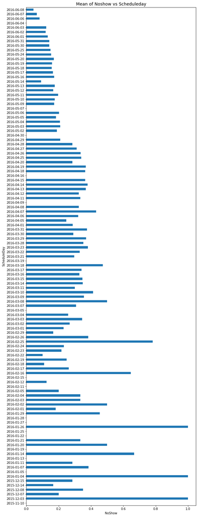

```python
horizontalbarChart(Scheduleday,'NoShow','ScheduleDay','Mean of Noshow vs Scheduleday', (10,30))
```

### Research Question 2: will patients with scholarship show up for appointment?

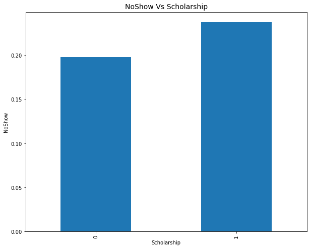

```python
#Groupby Scholarship find the mean of the relationship between Scholarship and NoShow
# And represent the infomation in a bar chart
scholarship = df.groupby('Scholarship').NoShow.mean()
verticalbarChart(scholarship,'Scholarship','NoShow','NoShow Vs Scholarship', (10,8) )
```

> The below code is to explore if patient with scholarship will show up for their appointment or not, from the the below graph, we can clearly see that most patients with scholarship would show up for their appointment

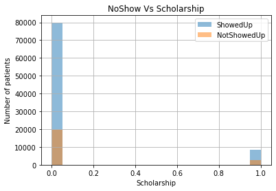

```python
df.Scholarship[ShowedUp].hist(alpha=0.5, bins=20, label='ShowedUp'),
df.Scholarship[NotShowedUp].hist(alpha=0.5, bins=20,label='NotShowedUp')
plt.title("NoShow Vs Scholarship")
plt.xlabel("Scholarship")
plt.ylabel("Number of patients")
plt.legend();
```

### Research Question 3: Is Gender Associated with NoSHow?

> The code below will compute the mean of those who did not showed up for appointment for the different gender

```python
df.groupby('Gender')['NoShow'].mean()
```

```
Gender
F    0.203146
M    0.199679
Name: NoShow, dtype: float64
```

> Below we can se the differences in the mean through the bar chat, we can see that the differences between the number of females who did not show up for the appointment and the number of men who did not show up for the appointment is insignificant

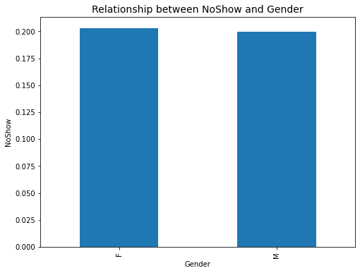

```python
gender = df.groupby('Gender')['NoShow'].mean()
verticalbarChart(gender,'Gender', 'NoShow', 'Relationship between NoShow and Gender', (8,6))
```

> The above graph is not accurate because i don't know how many males and females are involve, i want to check the number of males and female sheduled for appointment

```python
df.Gender.value_counts()
```

```
F    71840
M    38687
Name: Gender, dtype: int64
```

> From the above statistics, we can see that there are more females than males, so we cannot conclude that a particular gender will not respect appointmen most often

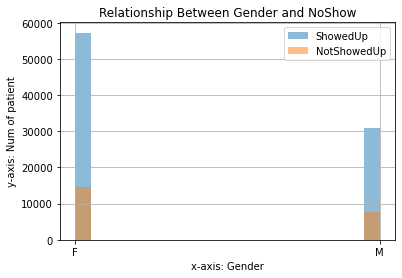

```python
df.Gender[ShowedUp].hist(alpha=0.5, bins=20, label='ShowedUp'),
df.Gender[NotShowedUp].hist(alpha=0.5, bins=20,label='NotShowedUp')
plt.title("Relationship Between Gender and NoShow")
plt.xlabel("x-axis: Gender")
plt.ylabel("y-axis: Num of patient")
plt.legend();
```

### Research Question 4: Will Handicap patients show up for their Appointments

> To start with, the below code will exploy all the unique values of the Handicap column

```python
df['Handcap'].unique()
```

```
array([0, 1, 2, 3, 4], dtype=int64)
```

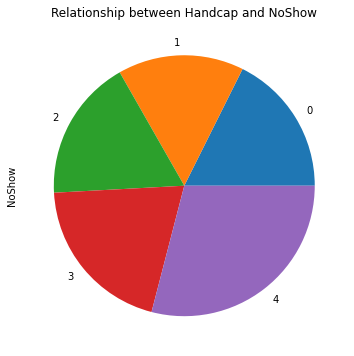

```python
#Here i am going o groupby Handicap, find the relationship betweeen Handicap and NoShow then compute the mean
df.groupby('Handcap')['NoShow'].mean().plot(kind="pie", figsize=(6,6))
plt.title('Relationship between Handcap and NoShow')
```

### Research Question 5: Will Hipertension patients show up for their Scheduled appointment?

> The code below , i want to represent the relationship between Hipertension and NoShow in a histogram

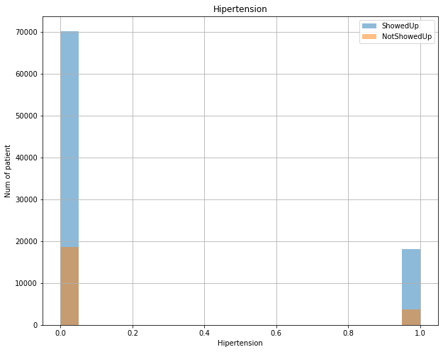

```python
df.Hipertension[ShowedUp].hist(alpha=0.5, bins=20, label='ShowedUp', figsize =(10,8)),
df.Hipertension[NotShowedUp].hist(alpha=0.5, bins=20,label='NotShowedUp');
plt.title("Hipertension")
plt.xlabel("Hipertension")
plt.ylabel("Num of patient")
plt.legend();
```

> The goal of the below code cell is to calculate the mean of those with Hypertension and will not show up for their appointment

```python
df.groupby('Hipertension').NoShow.mean()
```

```
Hipertension
0    0.209037
1    0.173020
Name: NoShow, dtype: float64
```

### Research Question 6: Will patients who receive SMS show up for their Scheduled appointment?

> In the cells bellow i want to explore if patients who receive sms will show up for their scheduled appointments

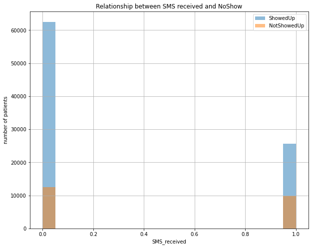

```python
df.SMS_received[ShowedUp].hist(alpha=0.5, bins=20, label='ShowedUp', figsize = (10,8)),
df.SMS_received[NotShowedUp].hist(alpha=0.5, bins=20,label='NotShowedUp');
plt.title("Relationship between SMS received and NoShow")
plt.xlabel("SMS_received")
plt.ylabel("number of patients")
plt.legend();
```

> The goal of the below code cell is to calculate the mean of those who received SMS and will or will not show up for their appointment

```python
df.groupby('SMS_received').NoShow.mean()
```

```
SMS_received
0    0.167033
1    0.275745
Name: NoShow, dtype: float64
```

## Conclusions

> The Udacity class room has been my guide throughout this project with the help my course mate who gave me a head up on how to create a resusable function to plot charts

> stackoverflow.com .

> > str.replace() function, dt.time, dt.date pd.to_datetime() and df.replace() function

## Limitations

> During this project, i had limitations in doing advanced analysis and creating functions that i could reuse due to limited knowledge. Again, i could not effectively use matplotlib library to create advanced visualisations due to limited knowledge